# 1US0 TYR Ring_0_0.2_10_Difference

11/51

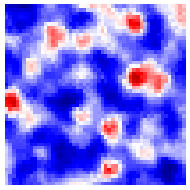

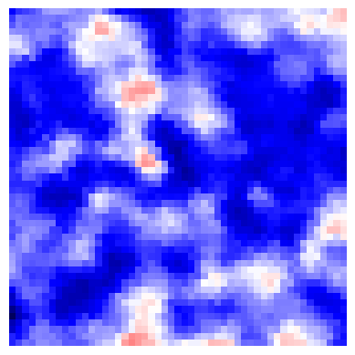

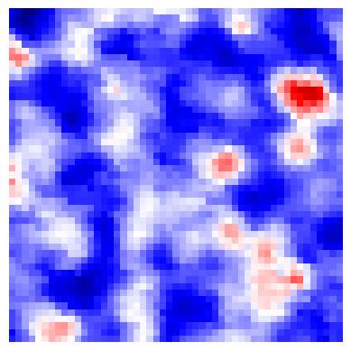

12/51

12/51

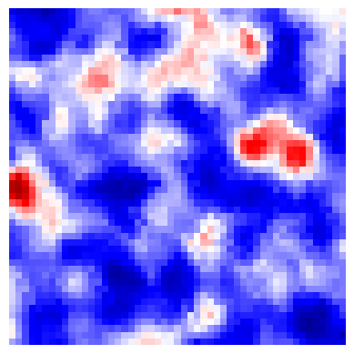

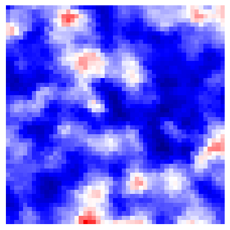

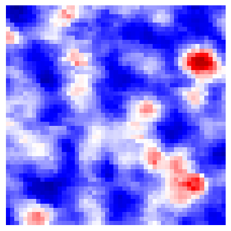

13/51

13/51

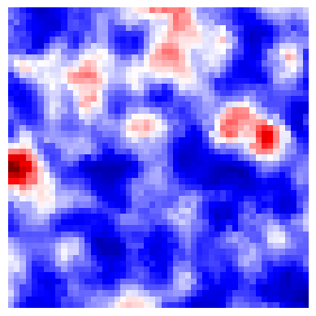

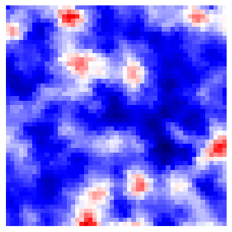

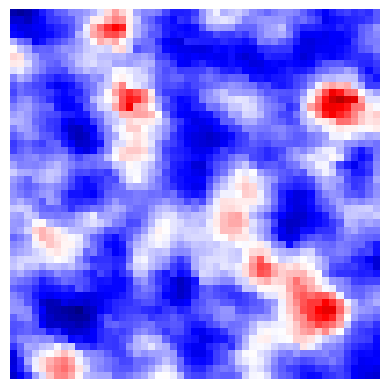

14/51

14/51

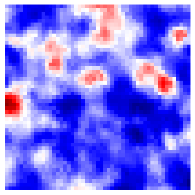

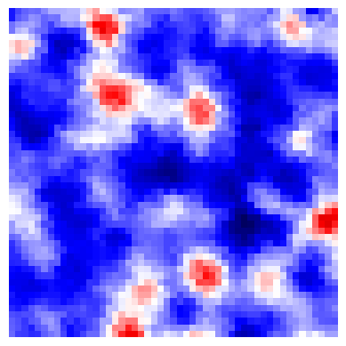

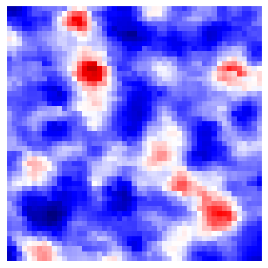

15/51

15/51

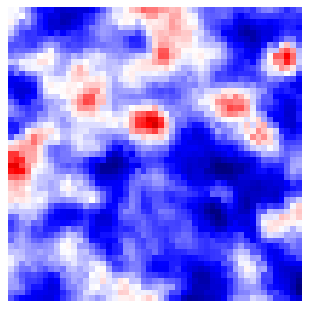

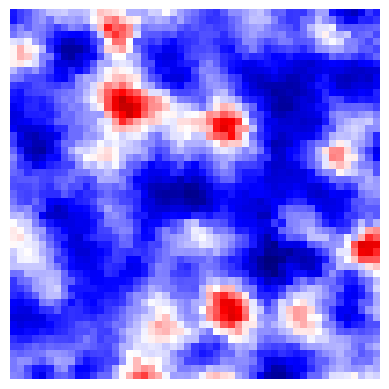

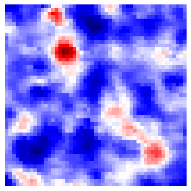

16/51

16/51

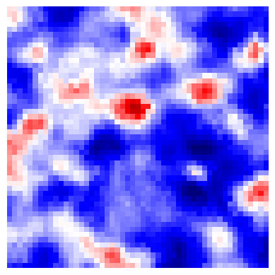

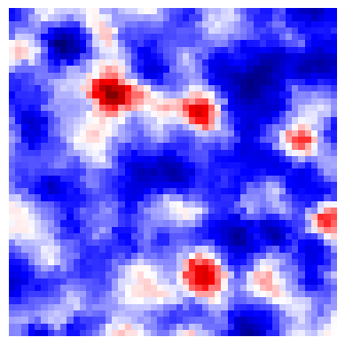

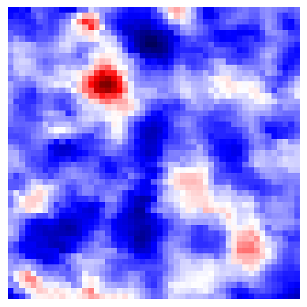

17/51

17/51

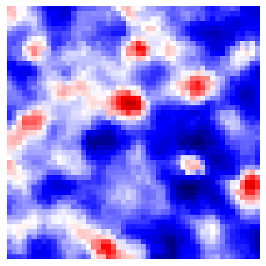

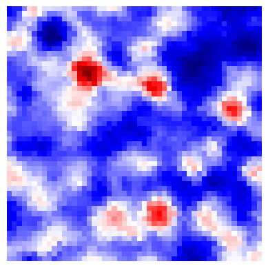

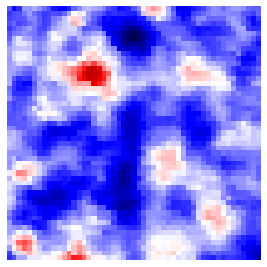

18/51

18/51

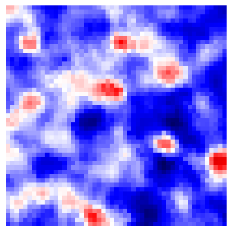

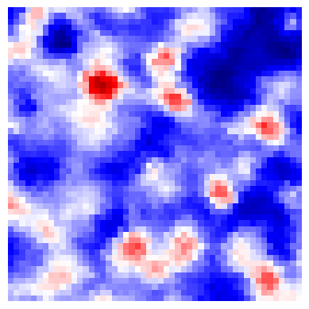

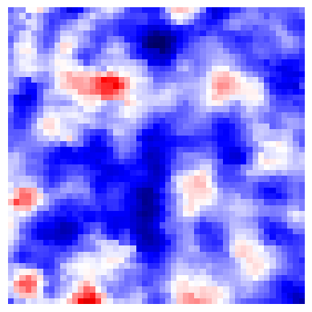

19/51

19/51

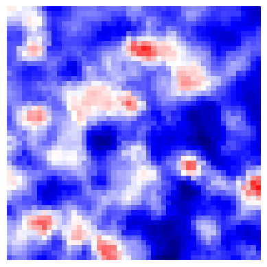

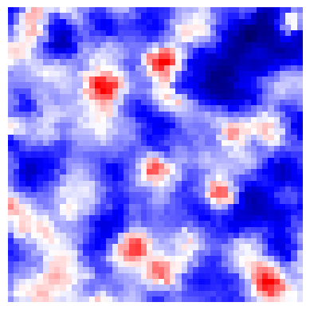

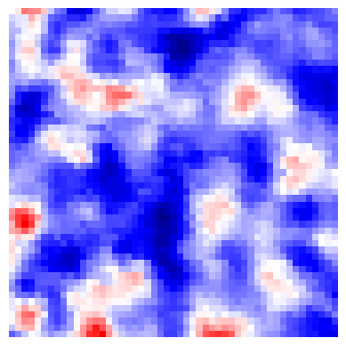

20/51

20/51

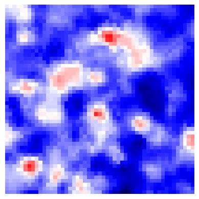

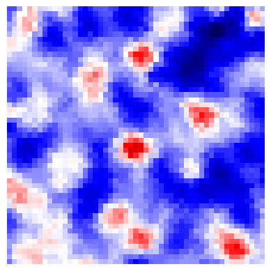

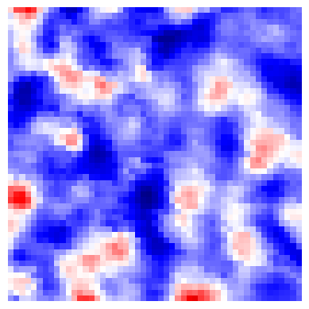

21/51

21/51

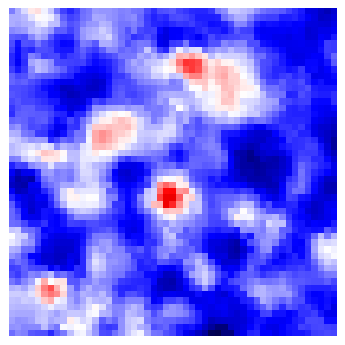

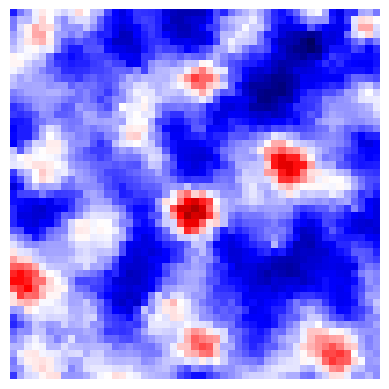

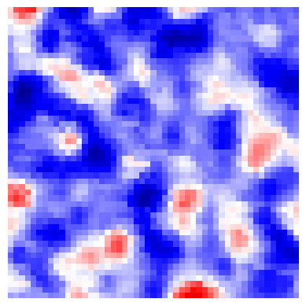

22/51

22/51

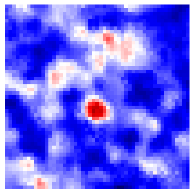

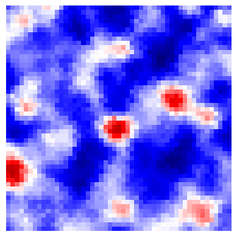

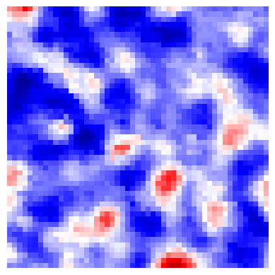

23/51

23/51

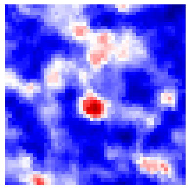

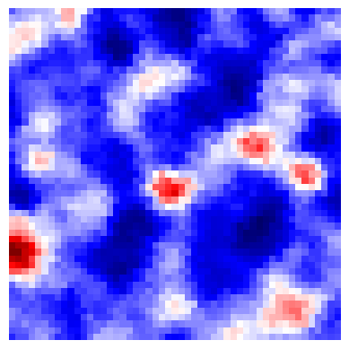

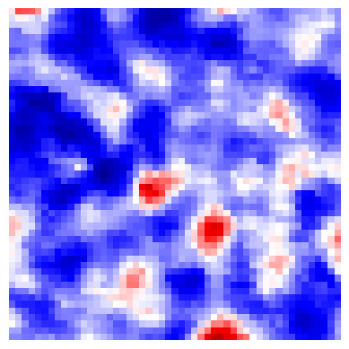

24/51

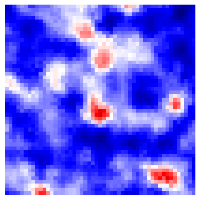

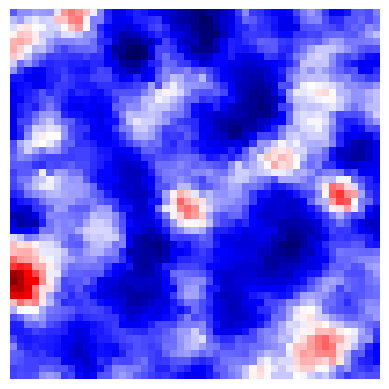

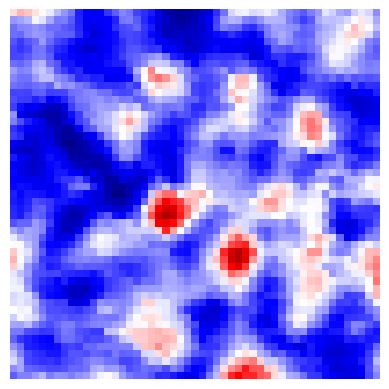

25/51

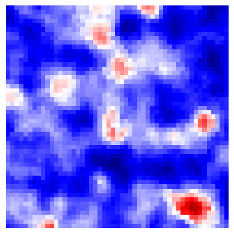

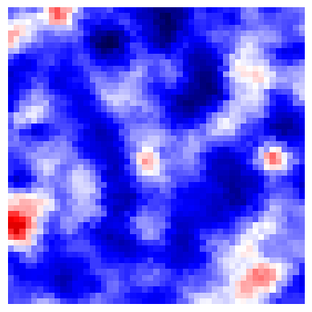

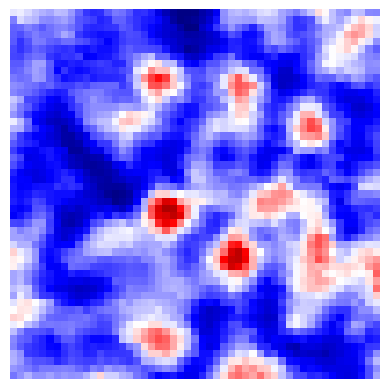

26/51

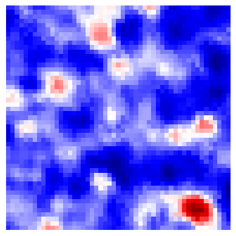

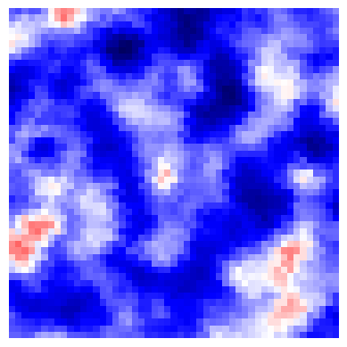

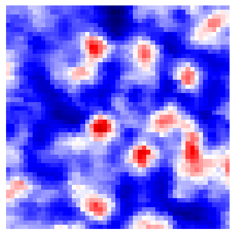

27/51

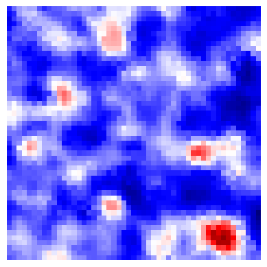

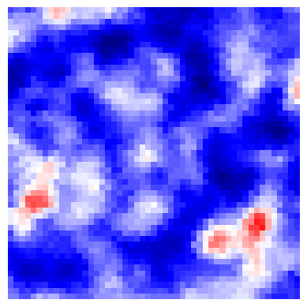

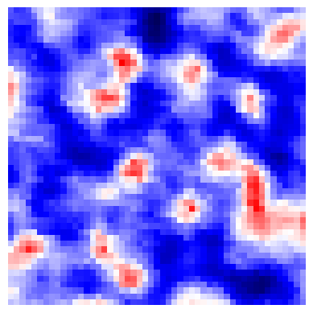

28/51

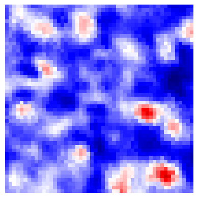

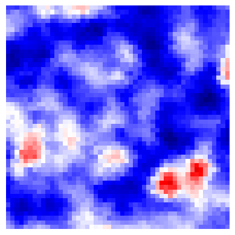

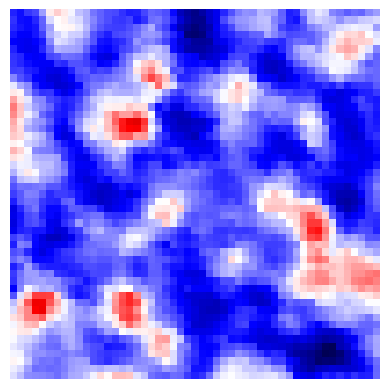

29/51

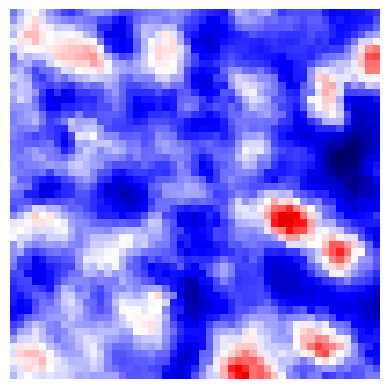

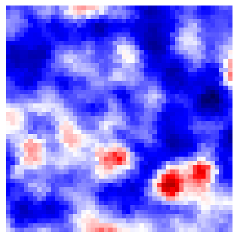

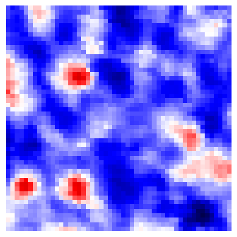

30/51

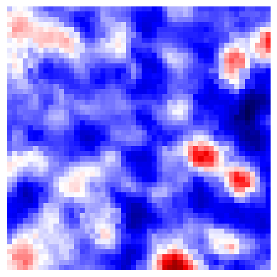

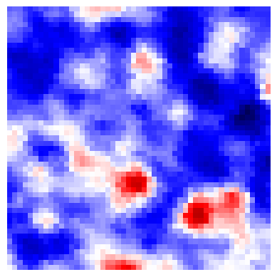

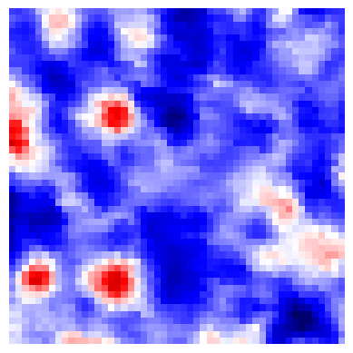

31/51